# Assignment1_Data621

Mubashira Qari

2025-02-09

## Data Exploration

### Loading Datasets

```r
eval_data <- read.csv("https://raw.githubusercontent.com/uzmabb182/Data_621/refs/heads/main/Assignment1/moneyball-evaluation-data%20(1).csv")

train_data <- read.csv("https://raw.githubusercontent.com/uzmabb182/Data_621/refs/heads/main/Assignment1/moneyball-training-data%20(1).csv")

head(eval_data)
```

|  | INDEX | TEAM_BATTING_H | TEAM_BATTING_2B | TEAM_BATTING_3B | TEAM_BATTING_HR | TEAM_BATTING_BB | TEAM_BATTING_SO | TEAM_BASERUN_SB | TEAM_BASERUN_CS | TEAM_BATTING_HBP | TEAM_PITCHING_H | TEAM_PITCHING_HR | TEAM_PITCHING_BB | TEAM_PITCHING_SO | TEAM_FIELDING_E | TEAM_FIELDING_DP |
| --- | --- | --- | --- | --- | --- | --- | --- | --- | --- | --- | --- | --- | --- | --- | --- | --- |
| 1 | 9 | 1209 | 170 | 33 | 83 | 447 | 1080 | 62 | 50 | NA | 1209 | 83 | 447 | 1080 | 140 | 156 |
| 2 | 10 | 1221 | 151 | 29 | 88 | 516 | 929 | 54 | 39 | NA | 1221 | 88 | 516 | 929 | 135 | 164 |
| 3 | 14 | 1395 | 183 | 29 | 93 | 509 | 816 | 59 | 47 | NA | 1395 | 93 | 509 | 816 | 156 | 153 |
| 4 | 47 | 1539 | 309 | 29 | 159 | 486 | 914 | 148 | 57 | 42 | 1539 | 159 | 486 | 914 | 124 | 154 |
| 5 | 60 | 1445 | 203 | 68 | 5 | 95 | 416 | NA | NA | NA | 3902 | 14 | 257 | 1123 | 616 | 130 |
| 6 | 63 | 1431 | 236 | 53 | 10 | 215 | 377 | NA | NA | NA | 2793 | 20 | 420 | 736 | 572 | 105 |

```r
head(train_data)
```

|  | INDEX | TARGET_WINS | TEAM_BATTING_H | TEAM_BATTING_2B | TEAM_BATTING_3B | TEAM_BATTING_HR | TEAM_BATTING_BB | TEAM_BATTING_SO | TEAM_BASERUN_SB | TEAM_BASERUN_CS | TEAM_BATTING_HBP | TEAM_PITCHING_H | TEAM_PITCHING_HR | TEAM_PITCHING_BB | TEAM_PITCHING_SO | TEAM_FIELDING_E | TEAM_FIELDING_DP |
| --- | --- | --- | --- | --- | --- | --- | --- | --- | --- | --- | --- | --- | --- | --- | --- | --- | --- |
| 1 | 1 | 39 | 1445 | 194 | 39 | 13 | 143 | 842 | NA | NA | NA | 9364 | 84 | 927 | 5456 | 1011 | NA |
| 2 | 2 | 70 | 1339 | 219 | 22 | 190 | 685 | 1075 | 37 | 28 | NA | 1347 | 191 | 689 | 1082 | 193 | 155 |
| 3 | 3 | 86 | 1377 | 232 | 35 | 137 | 602 | 917 | 46 | 27 | NA | 1377 | 137 | 602 | 917 | 175 | 153 |
| 4 | 4 | 70 | 1387 | 209 | 38 | 96 | 451 | 922 | 43 | 30 | NA | 1396 | 97 | 454 | 928 | 164 | 156 |
| 5 | 5 | 82 | 1297 | 186 | 27 | 102 | 472 | 920 | 49 | 39 | NA | 1297 | 102 | 472 | 920 | 138 | 168 |
| 6 | 6 | 75 | 1279 | 200 | 36 | 92 | 443 | 973 | 107 | 59 | NA | 1279 | 92 | 443 | 973 | 123 | 149 |

### Understanding the TARGET_WINS Field in the Moneyball Dataset:

The TARGET_WINS field represents the number of games a team won in a given baseball season.

This is the dependent variable (target variable) in the multiple linear regression model.

We are trying to predict TARGET_WINS based on other team performance metrics.

### Viewing Column Names

```r
names(eval_data)
```

```
##  [1] "INDEX"            "TEAM_BATTING_H"   "TEAM_BATTING_2B"  "TEAM_BATTING_3B"
##  [5] "TEAM_BATTING_HR"  "TEAM_BATTING_BB"  "TEAM_BATTING_SO"  "TEAM_BASERUN_SB"
##  [9] "TEAM_BASERUN_CS"  "TEAM_BATTING_HBP" "TEAM_PITCHING_H"  "TEAM_PITCHING_HR"
## [13] "TEAM_PITCHING_BB" "TEAM_PITCHING_SO" "TEAM_FIELDING_E"  "TEAM_FIELDING_DP"
```

```r
names(train_data)
```

```
##  [1] "INDEX"            "TARGET_WINS"      "TEAM_BATTING_H"   "TEAM_BATTING_2B"
##  [5] "TEAM_BATTING_3B"  "TEAM_BATTING_HR"  "TEAM_BATTING_BB"  "TEAM_BATTING_SO"
##  [9] "TEAM_BASERUN_SB"  "TEAM_BASERUN_CS"  "TEAM_BATTING_HBP" "TEAM_PITCHING_H"
## [13] "TEAM_PITCHING_HR" "TEAM_PITCHING_BB" "TEAM_PITCHING_SO" "TEAM_FIELDING_E"
## [17] "TEAM_FIELDING_DP"
```

### Viewing Field Values:

We can see there are fields with null values

```r
glimpse(eval_data)
```

```
## Rows: 259
## Columns: 16
## $ INDEX            <int> 9, 10, 14, 47, 60, 63, 74, 83, 98, 120, 123, 135, 138…
## $ TEAM_BATTING_H   <int> 1209, 1221, 1395, 1539, 1445, 1431, 1430, 1385, 1259,…
## $ TEAM_BATTING_2B  <int> 170, 151, 183, 309, 203, 236, 219, 158, 177, 212, 243…
## $ TEAM_BATTING_3B  <int> 33, 29, 29, 29, 68, 53, 55, 42, 78, 42, 40, 55, 57, 2…
## $ TEAM_BATTING_HR  <int> 83, 88, 93, 159, 5, 10, 37, 33, 23, 58, 50, 164, 186,…
## $ TEAM_BATTING_BB  <int> 447, 516, 509, 486, 95, 215, 568, 356, 466, 452, 495,…
## $ TEAM_BATTING_SO  <int> 1080, 929, 816, 914, 416, 377, 527, 609, 689, 584, 64…
## $ TEAM_BASERUN_SB  <int> 62, 54, 59, 148, NA, NA, 365, 185, 150, 52, 64, 48, 3…
## $ TEAM_BASERUN_CS  <int> 50, 39, 47, 57, NA, NA, NA, NA, NA, NA, NA, 28, 21, 8…
## $ TEAM_BATTING_HBP <int> NA, NA, NA, 42, NA, NA, NA, NA, NA, NA, NA, NA, NA, N…
## $ TEAM_PITCHING_H  <int> 1209, 1221, 1395, 1539, 3902, 2793, 1544, 1626, 1342,…
## $ TEAM_PITCHING_HR <int> 83, 88, 93, 159, 14, 20, 40, 39, 25, 62, 53, 173, 196…
## $ TEAM_PITCHING_BB <int> 447, 516, 509, 486, 257, 420, 613, 418, 497, 482, 521…
## $ TEAM_PITCHING_SO <int> 1080, 929, 816, 914, 1123, 736, 569, 715, 734, 622, 6…
## $ TEAM_FIELDING_E  <int> 140, 135, 156, 124, 616, 572, 490, 328, 226, 184, 200…
## $ TEAM_FIELDING_DP <int> 156, 164, 153, 154, 130, 105, NA, 104, 132, 145, 183,…
```

```r
glimpse(train_data)
```

```
## Rows: 2,276
## Columns: 17
## $ INDEX            <int> 1, 2, 3, 4, 5, 6, 7, 8, 11, 12, 13, 15, 16, 17, 18, 1…
## $ TARGET_WINS      <int> 39, 70, 86, 70, 82, 75, 80, 85, 86, 76, 78, 68, 72, 7…
## $ TEAM_BATTING_H   <int> 1445, 1339, 1377, 1387, 1297, 1279, 1244, 1273, 1391,…
## $ TEAM_BATTING_2B  <int> 194, 219, 232, 209, 186, 200, 179, 171, 197, 213, 179…
## $ TEAM_BATTING_3B  <int> 39, 22, 35, 38, 27, 36, 54, 37, 40, 18, 27, 31, 41, 2…
## $ TEAM_BATTING_HR  <int> 13, 190, 137, 96, 102, 92, 122, 115, 114, 96, 82, 95,…
## $ TEAM_BATTING_BB  <int> 143, 685, 602, 451, 472, 443, 525, 456, 447, 441, 374…
## $ TEAM_BATTING_SO  <int> 842, 1075, 917, 922, 920, 973, 1062, 1027, 922, 827, …
## $ TEAM_BASERUN_SB  <int> NA, 37, 46, 43, 49, 107, 80, 40, 69, 72, 60, 119, 221…
## $ TEAM_BASERUN_CS  <int> NA, 28, 27, 30, 39, 59, 54, 36, 27, 34, 39, 79, 109, …
## $ TEAM_BATTING_HBP <int> NA, NA, NA, NA, NA, NA, NA, NA, NA, NA, NA, NA, NA, N…
## $ TEAM_PITCHING_H  <int> 9364, 1347, 1377, 1396, 1297, 1279, 1244, 1281, 1391,…
## $ TEAM_PITCHING_HR <int> 84, 191, 137, 97, 102, 92, 122, 116, 114, 96, 86, 95,…
## $ TEAM_PITCHING_BB <int> 927, 689, 602, 454, 472, 443, 525, 459, 447, 441, 391…
## $ TEAM_PITCHING_SO <int> 5456, 1082, 917, 928, 920, 973, 1062, 1033, 922, 827,…
## $ TEAM_FIELDING_E  <int> 1011, 193, 175, 164, 138, 123, 136, 112, 127, 131, 11…
## $ TEAM_FIELDING_DP <int> NA, 155, 153, 156, 168, 149, 186, 136, 169, 159, 141,…
```

### Creating Dataframe

```r
eval_df <- data.frame(eval_data)
train_df <- data.frame(train_data)
train_df
```

| INDEX | TARGET_WINS | TEAM_BATTING_H | TEAM_BATTING_2B | TEAM_BATTING_3B | TEAM_BATTING_HR | TEAM_BATTING_BB | TEAM_BATTING_SO | TEAM_BASERUN_SB | TEAM_BASERUN_CS | TEAM_BATTING_HBP | TEAM_PITCHING_H | TEAM_PITCHING_HR | TEAM_PITCHING_BB | TEAM_PITCHING_SO | TEAM_FIELDING_E | TEAM_FIELDING_DP |
| --- | --- | --- | --- | --- | --- | --- | --- | --- | --- | --- | --- | --- | --- | --- | --- | --- |
| 1 | 39 | 1445 | 194 | 39 | 13 | 143 | 842 | NA | NA | NA | 9364 | 84 | 927 | 5456 | 1011 | NA |
| 2 | 70 | 1339 | 219 | 22 | 190 | 685 | 1075 | 37 | 28 | NA | 1347 | 191 | 689 | 1082 | 193 | 155 |
| 3 | 86 | 1377 | 232 | 35 | 137 | 602 | 917 | 46 | 27 | NA | 1377 | 137 | 602 | 917 | 175 | 153 |
| 4 | 70 | 1387 | 209 | 38 | 96 | 451 | 922 | 43 | 30 | NA | 1396 | 97 | 454 | 928 | 164 | 156 |
| 5 | 82 | 1297 | 186 | 27 | 102 | 472 | 920 | 49 | 39 | NA | 1297 | 102 | 472 | 920 | 138 | 168 |
| 6 | 75 | 1279 | 200 | 36 | 92 | 443 | 973 | 107 | 59 | NA | 1279 | 92 | 443 | 973 | 123 | 149 |
| 7 | 80 | 1244 | 179 | 54 | 122 | 525 | 1062 | 80 | 54 | NA | 1244 | 122 | 525 | 1062 | 136 | 186 |
| 8 | 85 | 1273 | 171 | 37 | 115 | 456 | 1027 | 40 | 36 | NA | 1281 | 116 | 459 | 1033 | 112 | 136 |
| 11 | 86 | 1391 | 197 | 40 | 114 | 447 | 922 | 69 | 27 | NA | 1391 | 114 | 447 | 922 | 127 | 169 |
| 12 | 76 | 1271 | 213 | 18 | 96 | 441 | 827 | 72 | 34 | NA | 1271 | 96 | 441 | 827 | 131 | 159 |

[output cut: 2266 more lines]

```r
str(eval_df)
```

```
## 'data.frame':    259 obs. of  16 variables:
##  $ INDEX           : int  9 10 14 47 60 63 74 83 98 120 ...
##  $ TEAM_BATTING_H  : int  1209 1221 1395 1539 1445 1431 1430 1385 1259 1397 ...
##  $ TEAM_BATTING_2B : int  170 151 183 309 203 236 219 158 177 212 ...
##  $ TEAM_BATTING_3B : int  33 29 29 29 68 53 55 42 78 42 ...
##  $ TEAM_BATTING_HR : int  83 88 93 159 5 10 37 33 23 58 ...
##  $ TEAM_BATTING_BB : int  447 516 509 486 95 215 568 356 466 452 ...
##  $ TEAM_BATTING_SO : int  1080 929 816 914 416 377 527 609 689 584 ...
##  $ TEAM_BASERUN_SB : int  62 54 59 148 NA NA 365 185 150 52 ...
##  $ TEAM_BASERUN_CS : int  50 39 47 57 NA NA NA NA NA NA ...
##  $ TEAM_BATTING_HBP: int  NA NA NA 42 NA NA NA NA NA NA ...
##  $ TEAM_PITCHING_H : int  1209 1221 1395 1539 3902 2793 1544 1626 1342 1489 ...
##  $ TEAM_PITCHING_HR: int  83 88 93 159 14 20 40 39 25 62 ...
##  $ TEAM_PITCHING_BB: int  447 516 509 486 257 420 613 418 497 482 ...
##  $ TEAM_PITCHING_SO: int  1080 929 816 914 1123 736 569 715 734 622 ...
##  $ TEAM_FIELDING_E : int  140 135 156 124 616 572 490 328 226 184 ...
##  $ TEAM_FIELDING_DP: int  156 164 153 154 130 105 NA 104 132 145 ...
```

```r
str(train_df)
```

```
## 'data.frame':    2276 obs. of  17 variables:
##  $ INDEX           : int  1 2 3 4 5 6 7 8 11 12 ...
##  $ TARGET_WINS     : int  39 70 86 70 82 75 80 85 86 76 ...
##  $ TEAM_BATTING_H  : int  1445 1339 1377 1387 1297 1279 1244 1273 1391 1271 ...
##  $ TEAM_BATTING_2B : int  194 219 232 209 186 200 179 171 197 213 ...
##  $ TEAM_BATTING_3B : int  39 22 35 38 27 36 54 37 40 18 ...
##  $ TEAM_BATTING_HR : int  13 190 137 96 102 92 122 115 114 96 ...
##  $ TEAM_BATTING_BB : int  143 685 602 451 472 443 525 456 447 441 ...
##  $ TEAM_BATTING_SO : int  842 1075 917 922 920 973 1062 1027 922 827 ...
##  $ TEAM_BASERUN_SB : int  NA 37 46 43 49 107 80 40 69 72 ...
##  $ TEAM_BASERUN_CS : int  NA 28 27 30 39 59 54 36 27 34 ...
##  $ TEAM_BATTING_HBP: int  NA NA NA NA NA NA NA NA NA NA ...
##  $ TEAM_PITCHING_H : int  9364 1347 1377 1396 1297 1279 1244 1281 1391 1271 ...
##  $ TEAM_PITCHING_HR: int  84 191 137 97 102 92 122 116 114 96 ...
##  $ TEAM_PITCHING_BB: int  927 689 602 454 472 443 525 459 447 441 ...
##  $ TEAM_PITCHING_SO: int  5456 1082 917 928 920 973 1062 1033 922 827 ...
##  $ TEAM_FIELDING_E : int  1011 193 175 164 138 123 136 112 127 131 ...
##  $ TEAM_FIELDING_DP: int  NA 155 153 156 168 149 186 136 169 159 ...
```

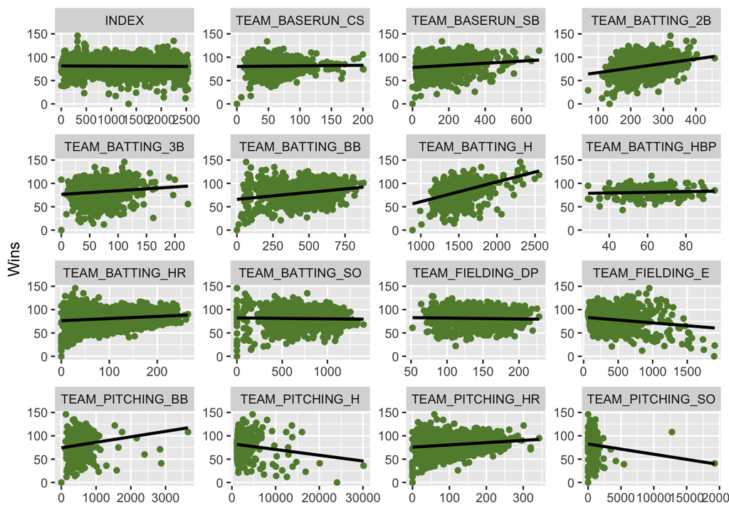

```r
train_df %>%
  gather(variable, value, -TARGET_WINS) %>%
  ggplot(., aes(value, TARGET_WINS)) +
  geom_point(fill = "#628B3A", color="#628B3A")  +
  geom_smooth(method = "lm", se = FALSE, color = "black") +
  facet_wrap(~variable, scales ="free", ncol = 4) +
  labs(x = element_blank(), y = "Wins")
```

### Sorted Correlations

```r
correlation_with_target <- cor(train_df, use = "complete.obs")["TARGET_WINS", ] %>%
  sort(decreasing = TRUE)  # Sort from highest to lowest correlation
print(correlation_with_target)
```

```
##      TARGET_WINS  TEAM_PITCHING_H   TEAM_BATTING_H  TEAM_BATTING_BB
##       1.00000000       0.47123431       0.46994665       0.46868793
## TEAM_PITCHING_BB TEAM_PITCHING_HR  TEAM_BATTING_HR  TEAM_BATTING_2B
##       0.46839882       0.42246683       0.42241683       0.31298400
## TEAM_BATTING_HBP  TEAM_BASERUN_SB            INDEX  TEAM_BATTING_3B
##       0.07350424       0.01483639      -0.04895047      -0.12434586
##  TEAM_BASERUN_CS TEAM_FIELDING_DP  TEAM_BATTING_SO TEAM_PITCHING_SO
##      -0.17875598      -0.19586601      -0.22889273      -0.22936481
##  TEAM_FIELDING_E
##      -0.38668800
```

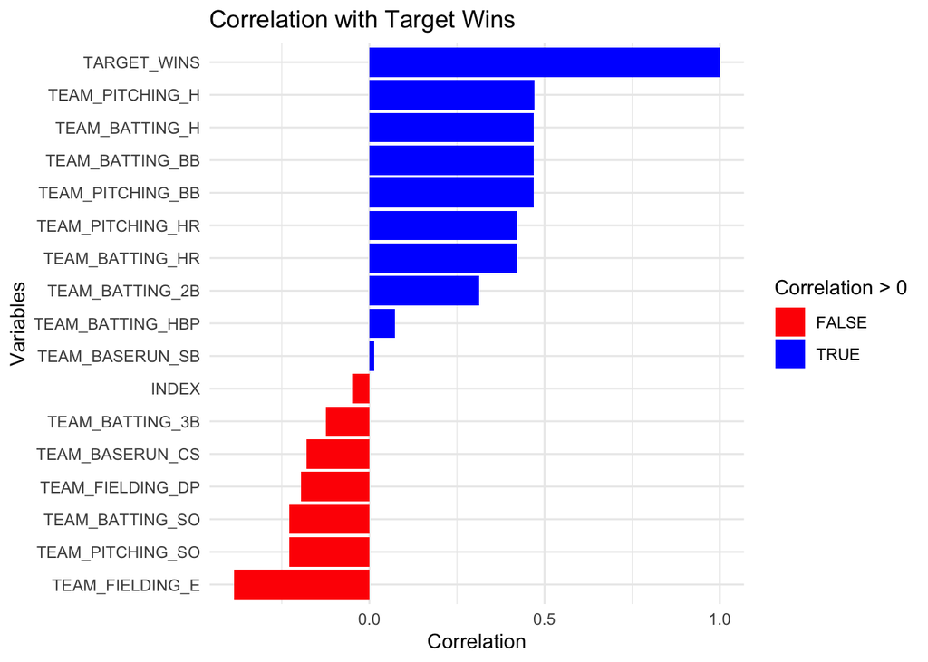

```r
library(ggplot2)

correlation_data <- data.frame(Variable = names(correlation_with_target), Correlation = correlation_with_target)

ggplot(correlation_data, aes(x = reorder(Variable, Correlation), y = Correlation, fill = Correlation > 0)) +
  geom_bar(stat = "identity") +
  coord_flip() +  # Flip for better readability
  labs(title = "Correlation with Target Wins", x = "Variables", y = "Correlation") +
  scale_fill_manual(values = c("red", "blue")) +
  theme_minimal()
```

### Checking Correlations and Finding Action:

Strong positive correlation (> 0.5) -> keep the variable in regression.

Strong negative correlation (< -0.5) -> Keep (inverse relationship).

Weak correlation (~0) -> Consider removing.

Two highly correlated variables (> 0.85) -> Drop one to avoid multicollinearity.

### Summary of Datasets

```r
skim(eval_df)
```

Data summary

| Name | eval_df |
| --- | --- |
| Number of rows | 259 |
| Number of columns | 16 |
| _______________________ |  |
| Column type frequency: |  |
| numeric | 16 |
| ________________________ |  |
| Group variables | None |

**Variable type: numeric**

| skim_variable | n_missing | complete_rate | mean | sd | p0 | p25 | p50 | p75 | p100 | hist |
| --- | --- | --- | --- | --- | --- | --- | --- | --- | --- | --- |
| INDEX | 0 | 1.00 | 1263.93 | 693.29 | 9 | 708.0 | 1249.0 | 1832.50 | 2525 | ▆▆▆▇▅ |
| TEAM_BATTING_H | 0 | 1.00 | 1469.39 | 150.66 | 819 | 1387.0 | 1455.0 | 1548.00 | 2170 | ▁▂▇▁▁ |
| TEAM_BATTING_2B | 0 | 1.00 | 241.32 | 49.52 | 44 | 210.0 | 239.0 | 278.50 | 376 | ▁▂▇▇▂ |
| TEAM_BATTING_3B | 0 | 1.00 | 55.91 | 27.14 | 14 | 35.0 | 52.0 | 72.00 | 155 | ▇▇▃▁▁ |
| TEAM_BATTING_HR | 0 | 1.00 | 95.63 | 56.33 | 0 | 44.5 | 101.0 | 135.50 | 242 | ▆▅▇▃▁ |
| TEAM_BATTING_BB | 0 | 1.00 | 498.96 | 120.59 | 15 | 436.5 | 509.0 | 565.50 | 792 | ▁▁▅▇▁ |
| TEAM_BATTING_SO | 18 | 0.93 | 709.34 | 243.11 | 0 | 545.0 | 686.0 | 912.00 | 1268 | ▁▃▇▇▂ |
| TEAM_BASERUN_SB | 13 | 0.95 | 123.70 | 93.39 | 0 | 59.0 | 92.0 | 151.75 | 580 | ▇▃▁▁▁ |
| TEAM_BASERUN_CS | 87 | 0.66 | 52.32 | 23.10 | 0 | 38.0 | 49.5 | 63.00 | 154 | ▂▇▃▁▁ |
| TEAM_BATTING_HBP | 240 | 0.07 | 62.37 | 12.71 | 42 | 53.5 | 62.0 | 67.50 | 96 | ▃▇▅▁▁ |
| TEAM_PITCHING_H | 0 | 1.00 | 1813.46 | 1662.91 | 1155 | 1426.5 | 1515.0 | 1681.00 | 22768 | ▇▁▁▁▁ |
| TEAM_PITCHING_HR | 0 | 1.00 | 102.15 | 57.65 | 0 | 52.0 | 104.0 | 142.50 | 336 | ▇▇▆▁▁ |
| TEAM_PITCHING_BB | 0 | 1.00 | 552.42 | 172.95 | 136 | 471.0 | 526.0 | 606.50 | 2008 | ▆▇▁▁▁ |
| TEAM_PITCHING_SO | 18 | 0.93 | 799.67 | 634.31 | 0 | 613.0 | 745.0 | 938.00 | 9963 | ▇▁▁▁▁ |
| TEAM_FIELDING_E | 0 | 1.00 | 249.75 | 230.90 | 73 | 131.0 | 163.0 | 252.00 | 1568 | ▇▁▁▁▁ |
| TEAM_FIELDING_DP | 31 | 0.88 | 146.06 | 25.88 | 69 | 131.0 | 148.0 | 164.00 | 204 | ▁▂▇▇▂ |

```r
skim(train_df)
```

Data summary

| Name | train_df |
| --- | --- |
| Number of rows | 2276 |
| Number of columns | 17 |
| _______________________ |  |
| Column type frequency: |  |
| numeric | 17 |
| ________________________ |  |
| Group variables | None |

**Variable type: numeric**

| skim_variable | n_missing | complete_rate | mean | sd | p0 | p25 | p50 | p75 | p100 | hist |
| --- | --- | --- | --- | --- | --- | --- | --- | --- | --- | --- |
| INDEX | 0 | 1.00 | 1268.46 | 736.35 | 1 | 630.75 | 1270.5 | 1915.50 | 2535 | ▇▇▇▇▇ |
| TARGET_WINS | 0 | 1.00 | 80.79 | 15.75 | 0 | 71.00 | 82.0 | 92.00 | 146 | ▁▁▇▅▁ |
| TEAM_BATTING_H | 0 | 1.00 | 1469.27 | 144.59 | 891 | 1383.00 | 1454.0 | 1537.25 | 2554 | ▁▇▂▁▁ |
| TEAM_BATTING_2B | 0 | 1.00 | 241.25 | 46.80 | 69 | 208.00 | 238.0 | 273.00 | 458 | ▁▆▇▂▁ |
| TEAM_BATTING_3B | 0 | 1.00 | 55.25 | 27.94 | 0 | 34.00 | 47.0 | 72.00 | 223 | ▇▇▂▁▁ |
| TEAM_BATTING_HR | 0 | 1.00 | 99.61 | 60.55 | 0 | 42.00 | 102.0 | 147.00 | 264 | ▇▆▇▅▁ |
| TEAM_BATTING_BB | 0 | 1.00 | 501.56 | 122.67 | 0 | 451.00 | 512.0 | 580.00 | 878 | ▁▁▇▇▁ |
| TEAM_BATTING_SO | 102 | 0.96 | 735.61 | 248.53 | 0 | 548.00 | 750.0 | 930.00 | 1399 | ▁▆▇▇▁ |
| TEAM_BASERUN_SB | 131 | 0.94 | 124.76 | 87.79 | 0 | 66.00 | 101.0 | 156.00 | 697 | ▇▃▁▁▁ |
| TEAM_BASERUN_CS | 772 | 0.66 | 52.80 | 22.96 | 0 | 38.00 | 49.0 | 62.00 | 201 | ▃▇▁▁▁ |
| TEAM_BATTING_HBP | 2085 | 0.08 | 59.36 | 12.97 | 29 | 50.50 | 58.0 | 67.00 | 95 | ▂▇▇▅▁ |
| TEAM_PITCHING_H | 0 | 1.00 | 1779.21 | 1406.84 | 1137 | 1419.00 | 1518.0 | 1682.50 | 30132 | ▇▁▁▁▁ |
| TEAM_PITCHING_HR | 0 | 1.00 | 105.70 | 61.30 | 0 | 50.00 | 107.0 | 150.00 | 343 | ▇▇▆▁▁ |
| TEAM_PITCHING_BB | 0 | 1.00 | 553.01 | 166.36 | 0 | 476.00 | 536.5 | 611.00 | 3645 | ▇▁▁▁▁ |
| TEAM_PITCHING_SO | 102 | 0.96 | 817.73 | 553.09 | 0 | 615.00 | 813.5 | 968.00 | 19278 | ▇▁▁▁▁ |
| TEAM_FIELDING_E | 0 | 1.00 | 246.48 | 227.77 | 65 | 127.00 | 159.0 | 249.25 | 1898 | ▇▁▁▁▁ |
| TEAM_FIELDING_DP | 286 | 0.87 | 146.39 | 26.23 | 52 | 131.00 | 149.0 | 164.00 | 228 | ▁▂▇▆▁ |

```r
summary(train_df)
```

```
##      INDEX         TARGET_WINS     TEAM_BATTING_H TEAM_BATTING_2B
##  Min.   :   1.0   Min.   :  0.00   Min.   : 891   Min.   : 69.0
##  1st Qu.: 630.8   1st Qu.: 71.00   1st Qu.:1383   1st Qu.:208.0
##  Median :1270.5   Median : 82.00   Median :1454   Median :238.0
##  Mean   :1268.5   Mean   : 80.79   Mean   :1469   Mean   :241.2
##  3rd Qu.:1915.5   3rd Qu.: 92.00   3rd Qu.:1537   3rd Qu.:273.0
##  Max.   :2535.0   Max.   :146.00   Max.   :2554   Max.   :458.0
##
##  TEAM_BATTING_3B  TEAM_BATTING_HR  TEAM_BATTING_BB TEAM_BATTING_SO
##  Min.   :  0.00   Min.   :  0.00   Min.   :  0.0   Min.   :   0.0
##  1st Qu.: 34.00   1st Qu.: 42.00   1st Qu.:451.0   1st Qu.: 548.0
##  Median : 47.00   Median :102.00   Median :512.0   Median : 750.0
##  Mean   : 55.25   Mean   : 99.61   Mean   :501.6   Mean   : 735.6
##  3rd Qu.: 72.00   3rd Qu.:147.00   3rd Qu.:580.0   3rd Qu.: 930.0
##  Max.   :223.00   Max.   :264.00   Max.   :878.0   Max.   :1399.0
##                                                    NA's   :102
##  TEAM_BASERUN_SB TEAM_BASERUN_CS TEAM_BATTING_HBP TEAM_PITCHING_H
##  Min.   :  0.0   Min.   :  0.0   Min.   :29.00    Min.   : 1137
##  1st Qu.: 66.0   1st Qu.: 38.0   1st Qu.:50.50    1st Qu.: 1419
##  Median :101.0   Median : 49.0   Median :58.00    Median : 1518
##  Mean   :124.8   Mean   : 52.8   Mean   :59.36    Mean   : 1779
##  3rd Qu.:156.0   3rd Qu.: 62.0   3rd Qu.:67.00    3rd Qu.: 1682
##  Max.   :697.0   Max.   :201.0   Max.   :95.00    Max.   :30132
##  NA's   :131     NA's   :772     NA's   :2085
##  TEAM_PITCHING_HR TEAM_PITCHING_BB TEAM_PITCHING_SO  TEAM_FIELDING_E
##  Min.   :  0.0    Min.   :   0.0   Min.   :    0.0   Min.   :  65.0
##  1st Qu.: 50.0    1st Qu.: 476.0   1st Qu.:  615.0   1st Qu.: 127.0
##  Median :107.0    Median : 536.5   Median :  813.5   Median : 159.0
##  Mean   :105.7    Mean   : 553.0   Mean   :  817.7   Mean   : 246.5
##  3rd Qu.:150.0    3rd Qu.: 611.0   3rd Qu.:  968.0   3rd Qu.: 249.2
##  Max.   :343.0    Max.   :3645.0   Max.   :19278.0   Max.   :1898.0
##                                    NA's   :102
##  TEAM_FIELDING_DP
##  Min.   : 52.0
##  1st Qu.:131.0
##  Median :149.0
##  Mean   :146.4
##  3rd Qu.:164.0
##  Max.   :228.0
##  NA's   :286
```

```r
summary(eval_df)
```

```
##      INDEX      TEAM_BATTING_H TEAM_BATTING_2B TEAM_BATTING_3B
##  Min.   :   9   Min.   : 819   Min.   : 44.0   Min.   : 14.00
##  1st Qu.: 708   1st Qu.:1387   1st Qu.:210.0   1st Qu.: 35.00
##  Median :1249   Median :1455   Median :239.0   Median : 52.00
##  Mean   :1264   Mean   :1469   Mean   :241.3   Mean   : 55.91
##  3rd Qu.:1832   3rd Qu.:1548   3rd Qu.:278.5   3rd Qu.: 72.00
##  Max.   :2525   Max.   :2170   Max.   :376.0   Max.   :155.00
##
##  TEAM_BATTING_HR  TEAM_BATTING_BB TEAM_BATTING_SO  TEAM_BASERUN_SB
##  Min.   :  0.00   Min.   : 15.0   Min.   :   0.0   Min.   :  0.0
##  1st Qu.: 44.50   1st Qu.:436.5   1st Qu.: 545.0   1st Qu.: 59.0
##  Median :101.00   Median :509.0   Median : 686.0   Median : 92.0
##  Mean   : 95.63   Mean   :499.0   Mean   : 709.3   Mean   :123.7
##  3rd Qu.:135.50   3rd Qu.:565.5   3rd Qu.: 912.0   3rd Qu.:151.8
##  Max.   :242.00   Max.   :792.0   Max.   :1268.0   Max.   :580.0
##                                   NA's   :18       NA's   :13
##  TEAM_BASERUN_CS  TEAM_BATTING_HBP TEAM_PITCHING_H TEAM_PITCHING_HR
##  Min.   :  0.00   Min.   :42.00    Min.   : 1155   Min.   :  0.0
##  1st Qu.: 38.00   1st Qu.:53.50    1st Qu.: 1426   1st Qu.: 52.0
##  Median : 49.50   Median :62.00    Median : 1515   Median :104.0
##  Mean   : 52.32   Mean   :62.37    Mean   : 1813   Mean   :102.1
##  3rd Qu.: 63.00   3rd Qu.:67.50    3rd Qu.: 1681   3rd Qu.:142.5
##  Max.   :154.00   Max.   :96.00    Max.   :22768   Max.   :336.0
##  NA's   :87       NA's   :240
##  TEAM_PITCHING_BB TEAM_PITCHING_SO TEAM_FIELDING_E  TEAM_FIELDING_DP
##  Min.   : 136.0   Min.   :   0.0   Min.   :  73.0   Min.   : 69.0
##  1st Qu.: 471.0   1st Qu.: 613.0   1st Qu.: 131.0   1st Qu.:131.0
##  Median : 526.0   Median : 745.0   Median : 163.0   Median :148.0
##  Mean   : 552.4   Mean   : 799.7   Mean   : 249.7   Mean   :146.1
##  3rd Qu.: 606.5   3rd Qu.: 938.0   3rd Qu.: 252.0   3rd Qu.:164.0
##  Max.   :2008.0   Max.   :9963.0   Max.   :1568.0   Max.   :204.0
##                   NA's   :18                        NA's   :31
```

### Calculate mean, median, and standard deviation for key numerical columns

```r
train_df %>%
  summarise(across(where(is.numeric), list(mean = mean, median = median, sd = sd), na.rm = TRUE))
```

| INDEX_mean | INDEX_median | INDEX_sd | TARGET_WINS_mean | TARGET_WINS_median | TARGET_WINS_sd | TEAM_BATTING_H_mean | TEAM_BATTING_H_median | TEAM_BATTING_H_sd | TEAM_BATTING_2B_mean | TEAM_BATTING_2B_median | TEAM_BATTING_2B_sd | TEAM_BATTING_3B_mean | TEAM_BATTING_3B_median | TEAM_BATTING_3B_sd | TEAM_BATTING_HR_mean | TEAM_BATTING_HR_median | TEAM_BATTING_HR_sd | TEAM_BATTING_BB_mean | TEAM_BATTING_BB_median | TEAM_BATTING_BB_sd | TEAM_BATTING_SO_mean | TEAM_BATTING_SO_median | TEAM_BATTING_SO_sd | TEAM_BASERUN_SB_mean | TEAM_BASERUN_SB_median | TEAM_BASERUN_SB_sd | TEAM_BASERUN_CS_mean | TEAM_BASERUN_CS_median | TEAM_BASERUN_CS_sd | … |
| --- | --- | --- | --- | --- | --- | --- | --- | --- | --- | --- | --- | --- | --- | --- | --- | --- | --- | --- | --- | --- | --- | --- | --- | --- | --- | --- | --- | --- | --- | --- |
| 1268.464 | 1270.5 | 736.349 | 80.79086 | 82 | 15.75215 | 1469.27 | 1454 | 144.5912 | 241.2469 | 238 | 46.80141 | 55.25 | 47 | 27.93856 | 99.61204 | 102 | 60.54687 | 501.5589 | 512 | 122.6709 | 735.6053 | 750 | 248.5264 | 124.7618 | 101 | 87.79117 | 52.80386 | 49 | 22.95634 | … |

The summarise(across()) function above is calculating the mean, median, ans standard deviation for all the numerical variables.

### Analysis of the training Dataset Before Fitting a Multiple Linear Regression Model:

Before fitting a multiple linear regression (MLR) model, we analyze the dataset for potential issues such as missing values, extreme outliers, multicollinearity, and variable distributions.

Here’s what we can infer from the summary statistics:

#### 1. Understanding the Target Variable (TARGET_WINS)

Range: 0 to 146 wins

Mean: ~80.79 wins

Median: 82 wins

Distribution: The min value of 0 and max of 146 suggest some potential outliers or erroneous data points, since most teams win between 50-110 games in a season.

#### 2. Missing Values

- Some variables have a significant number of missing values:

TEAM_BATTING_SO (102 missing values)

TEAM_BASERUN_SB (131 missing values)

TEAM_BASERUN_CS (772 missing values) <- potentially unreliable

TEAM_BATTING_HBP (2085 missing values) <- very unreliable

TEAM_PITCHING_SO (102 missing values)

TEAM_FIELDING_DP (286 missing values)

#### Actionable Steps:

- Impute missing values (using mean/median or regression techniques).
- Consider removing TEAM_BATTING_HBP and TEAM_BASERUN_CS if they are highly incomplete and do not contribute much.

#### 3. Potential Outliers & Data Issues

- Several variables have extreme max values that seem unrealistic:

TEAM_PITCHING_H (Max = 30,132) <- Likely an error since typical values range from 1,200 - 1,700.

TEAM_PITCHING_SO (Max = 19,278) <- Suspiciously high (typical range: 500 - 1,500).

TEAM_PITCHING_BB (Max = 3,645) <- Very high (typical range: 300 - 700).

TEAM_FIELDING_E (Max = 1,898) <- Likely an error since the normal range is ~ 70-200.

#### Actionable Steps:

- Check for data entry errors.
- Remove extreme outliers if they distort model performance.

#### 4. Feature Selection Considerations:

Batting Variables: TEAM_BATTING_H, TEAM_BATTING_2B, TEAM_BATTING_3B, TEAM_BATTING_HR, TEAM_BATTING_BB are likely strong predictors of team wins.

Pitching Variables: TEAM_PITCHING_H, TEAM_PITCHING_HR, TEAM_PITCHING_BB, TEAM_PITCHING_SO will impact defensive strength.

Fielding Variables: TEAM_FIELDING_E (errors) and TEAM_FIELDING_DP (double plays) may have a weaker impact compared to batting and pitching.

#### Multicollinearity Check Needed:

TEAM_PITCHING_H, TEAM_PITCHING_HR, and TEAM_PITCHING_BB may be highly correlated, which can cause multicollinearity in the regression model.

TEAM_BATTING_H, TEAM_BATTING_2B, and TEAM_BATTING_3B may also be strongly correlated since total hits include doubles and triples.

#### 5. Data Cleaning Recommendations Before Fitting the Model

Handle Missing Values

Consider dropping or imputing variables with too many missing values (e.g., TEAM_BATTING_HBP).

Impute TEAM_BASERUN_SB, TEAM_BASERUN_CS, and TEAM_FIELDING_DP appropriately.

- Remove or Adjust Extreme Outliers

Remove highly unrealistic values in pitching, fielding, and errors.

- Check for Multicollinearity

Use Variance Inflation Factor (VIF) to detect multicollinearity and drop redundant features.

- Feature Engineering

Consider derived metrics like batting average (H/AB), on-base percentage (OBP), or earned run average (ERA) instead of raw counts.

### Conclusion:

The dataset contains inconsistencies, missing values, and extreme outliers that need to be addressed before fitting an MLR model.

Once cleaned, feature selection and multicollinearity checks will be essential to ensure a robust and interpretable model for predicting team wins.

## Visualizing Training Dataset:

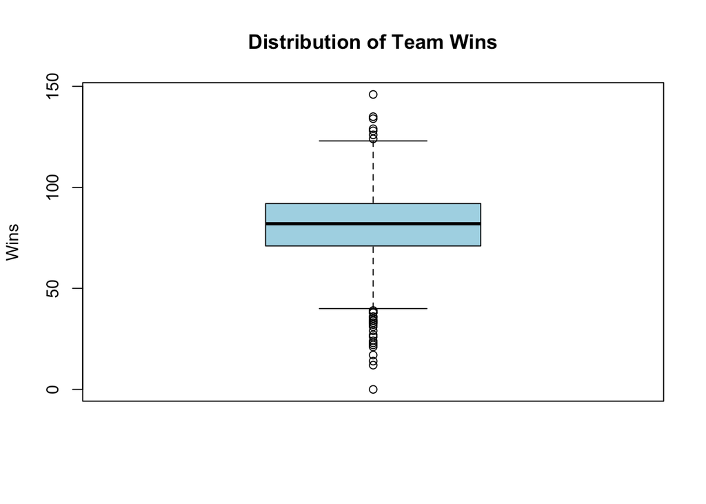

```r
boxplot(train_df$TARGET_WINS, main="Distribution of Team Wins", ylab="Wins", col="lightblue")
```

## Analysis of the Box Plot for TARGET_WINS (Team Wins Distribution)

This box plot provides valuable insights into the distribution of team wins in the training dataset.

Here’s what we can infer:

#### 1. Median and Spread of Wins

The thick horizontal line inside the box represents the median (~82 wins).

The box itself (Interquartile Range - IQR) shows the middle 50% of the data, which seems to range roughly from 70 to 92 wins.

### Consideration for Regression?

#### 3. Data Skewness and Symmetry

The box is fairly centered, suggesting a roughly symmetric distribution.

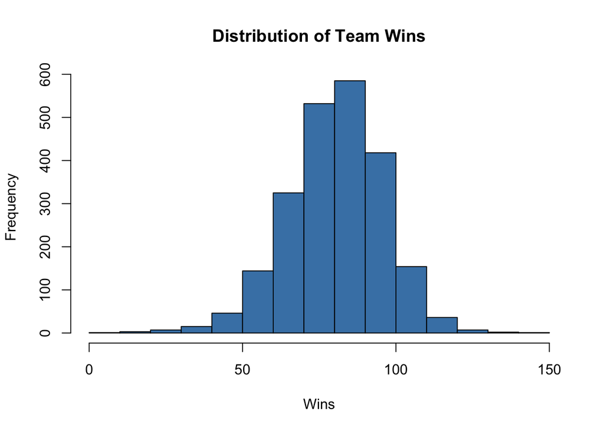

```r
hist(train_df$TARGET_WINS,
     main = "Distribution of Team Wins",
     xlab = "Wins",
     ylab = "Frequency",
     col = "steelblue",
     border = "black",
     breaks = 20)  # number of bins
```

### Histogram with Density Curve

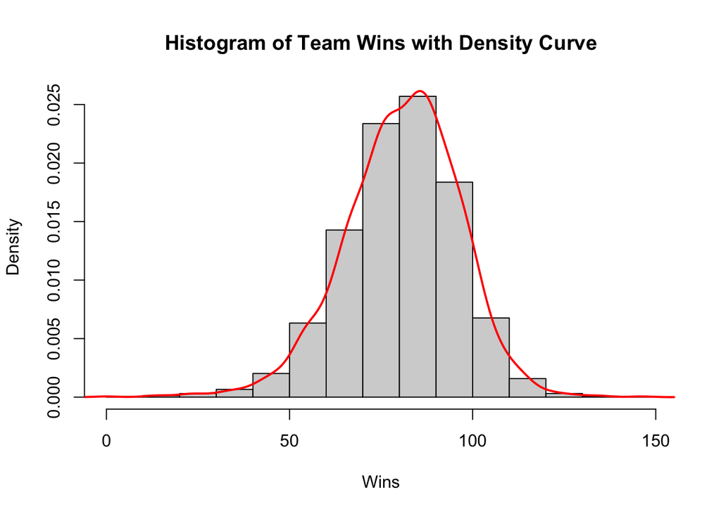

```r
hist(train_df$TARGET_WINS,
     main = "Histogram of Team Wins with Density Curve",
     xlab = "Wins",
     col = "lightgray",
     border = "black",
     breaks = 20,
     probability = TRUE)  # Converts y-axis to density

lines(density(train_df$TARGET_WINS, na.rm = TRUE),
      col = "red",
      lwd = 2)  # Adds a red density curve
```

## Data Preparation

- Analyze Missing Values from Train Datasets.

```r
#install.packages("naniar")     # Specialized for missing data visualization
#install.packages("visdat")     # Another missing value visualization package

library(naniar)
library(visdat)
library(dplyr)
library(tidyr)  # tidyr is loaded to use pivot_longer()
```

```r
missing_values <- train_df %>%
  summarise(across(everything(), ~ sum(is.na(.)))) %>%
  pivot_longer(cols = everything(), names_to = "Variable", values_to = "Missing_Count")

print(missing_values)
```

```
## # A tibble: 17 × 2
##    Variable         Missing_Count
##    <chr>                    <int>
##  1 INDEX                        0
##  2 TARGET_WINS                  0
##  3 TEAM_BATTING_H               0
##  4 TEAM_BATTING_2B              0
##  5 TEAM_BATTING_3B              0
##  6 TEAM_BATTING_HR              0
##  7 TEAM_BATTING_BB              0
##  8 TEAM_BATTING_SO            102
##  9 TEAM_BASERUN_SB            131
## 10 TEAM_BASERUN_CS            772
## 11 TEAM_BATTING_HBP          2085
## 12 TEAM_PITCHING_H              0
## 13 TEAM_PITCHING_HR             0
## 14 TEAM_PITCHING_BB             0
## 15 TEAM_PITCHING_SO           102
## 16 TEAM_FIELDING_E              0
## 17 TEAM_FIELDING_DP           286
```

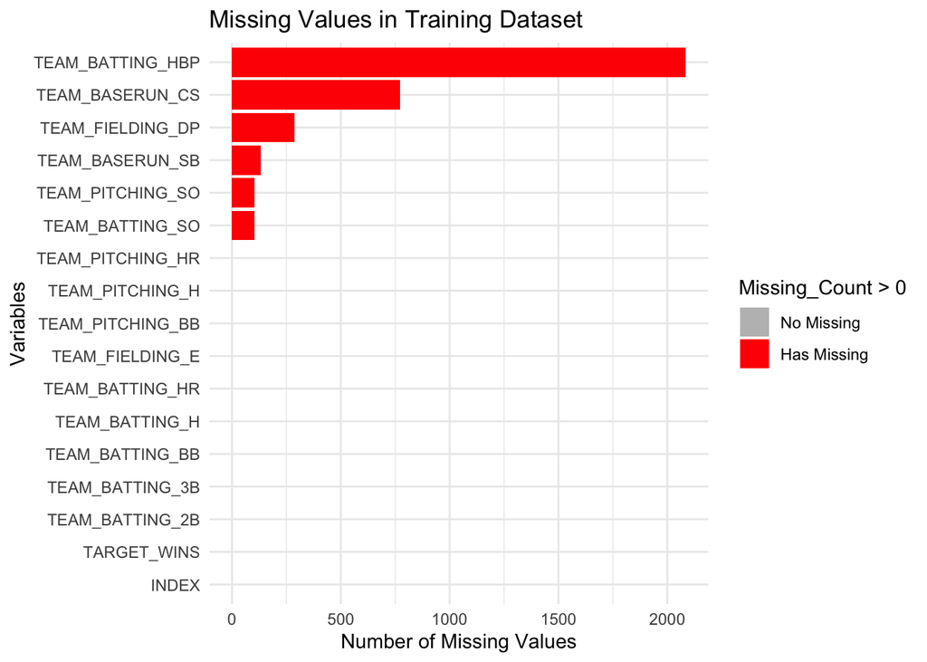

```r
ggplot(missing_values, aes(y = reorder(Variable, Missing_Count), x = Missing_Count, fill = Missing_Count > 0)) +
  geom_col() +
  labs(title = "Missing Values in Training Dataset",
       x = "Number of Missing Values",
       y = "Variables") +
  scale_fill_manual(values = c("gray", "red"), labels = c("No Missing", "Has Missing")) +
  theme_minimal()
```

### Strategy for Missing Values Column wise:

There are four main options for handling missing values:

#### 1. Remove Columns with Too Many Missing Values

If a column has too many missing values (e.g., >50% missing), it may be better to remove it.

The *TEAM_BATTING_HBP* column is mostly empty and not critical.

```r
library(naniar)
library(visdat)
library(dplyr)
library(tidyr)  # tidyr is loaded to use pivot_longer()

train_df <- train_df[, !names(train_df) %in% "INDEX"]
train_df <- train_df[, !names(train_df) %in% "TEAM_BATTING_HBP"]
train_df
```

| TARGET_WINS | TEAM_BATTING_H | TEAM_BATTING_2B | TEAM_BATTING_3B | TEAM_BATTING_HR | TEAM_BATTING_BB | TEAM_BATTING_SO | TEAM_BASERUN_SB | TEAM_BASERUN_CS | TEAM_PITCHING_H | TEAM_PITCHING_HR | TEAM_PITCHING_BB | TEAM_PITCHING_SO | TEAM_FIELDING_E | TEAM_FIELDING_DP |
| --- | --- | --- | --- | --- | --- | --- | --- | --- | --- | --- | --- | --- | --- | --- |
| 39 | 1445 | 194 | 39 | 13 | 143 | 842 | NA | NA | 9364 | 84 | 927 | 5456 | 1011 | NA |
| 70 | 1339 | 219 | 22 | 190 | 685 | 1075 | 37 | 28 | 1347 | 191 | 689 | 1082 | 193 | 155 |
| 86 | 1377 | 232 | 35 | 137 | 602 | 917 | 46 | 27 | 1377 | 137 | 602 | 917 | 175 | 153 |
| 70 | 1387 | 209 | 38 | 96 | 451 | 922 | 43 | 30 | 1396 | 97 | 454 | 928 | 164 | 156 |
| 82 | 1297 | 186 | 27 | 102 | 472 | 920 | 49 | 39 | 1297 | 102 | 472 | 920 | 138 | 168 |
| 75 | 1279 | 200 | 36 | 92 | 443 | 973 | 107 | 59 | 1279 | 92 | 443 | 973 | 123 | 149 |
| 80 | 1244 | 179 | 54 | 122 | 525 | 1062 | 80 | 54 | 1244 | 122 | 525 | 1062 | 136 | 186 |
| 85 | 1273 | 171 | 37 | 115 | 456 | 1027 | 40 | 36 | 1281 | 116 | 459 | 1033 | 112 | 136 |
| 86 | 1391 | 197 | 40 | 114 | 447 | 922 | 69 | 27 | 1391 | 114 | 447 | 922 | 127 | 169 |
| 76 | 1271 | 213 | 18 | 96 | 441 | 827 | 72 | 34 | 1271 | 96 | 441 | 827 | 131 | 159 |

[output cut: 2266 more lines]

#### 2. Remove Rows with Missing Target (TARGET_WINS)

If the TARGET_WINS column has missing values, remove those rows since we can’t predict missing outcomes.

```r
train_df <- train_df %>% filter(!is.na(TARGET_WINS))
train_df
```

| TARGET_WINS | TEAM_BATTING_H | TEAM_BATTING_2B | TEAM_BATTING_3B | TEAM_BATTING_HR | TEAM_BATTING_BB | TEAM_BATTING_SO | TEAM_BASERUN_SB | TEAM_BASERUN_CS | TEAM_PITCHING_H | TEAM_PITCHING_HR | TEAM_PITCHING_BB | TEAM_PITCHING_SO | TEAM_FIELDING_E | TEAM_FIELDING_DP |
| --- | --- | --- | --- | --- | --- | --- | --- | --- | --- | --- | --- | --- | --- | --- |
| 39 | 1445 | 194 | 39 | 13 | 143 | 842 | NA | NA | 9364 | 84 | 927 | 5456 | 1011 | NA |
| 70 | 1339 | 219 | 22 | 190 | 685 | 1075 | 37 | 28 | 1347 | 191 | 689 | 1082 | 193 | 155 |
| 86 | 1377 | 232 | 35 | 137 | 602 | 917 | 46 | 27 | 1377 | 137 | 602 | 917 | 175 | 153 |
| 70 | 1387 | 209 | 38 | 96 | 451 | 922 | 43 | 30 | 1396 | 97 | 454 | 928 | 164 | 156 |
| 82 | 1297 | 186 | 27 | 102 | 472 | 920 | 49 | 39 | 1297 | 102 | 472 | 920 | 138 | 168 |
| 75 | 1279 | 200 | 36 | 92 | 443 | 973 | 107 | 59 | 1279 | 92 | 443 | 973 | 123 | 149 |
| 80 | 1244 | 179 | 54 | 122 | 525 | 1062 | 80 | 54 | 1244 | 122 | 525 | 1062 | 136 | 186 |
| 85 | 1273 | 171 | 37 | 115 | 456 | 1027 | 40 | 36 | 1281 | 116 | 459 | 1033 | 112 | 136 |
| 86 | 1391 | 197 | 40 | 114 | 447 | 922 | 69 | 27 | 1391 | 114 | 447 | 922 | 127 | 169 |
| 76 | 1271 | 213 | 18 | 96 | 441 | 827 | 72 | 34 | 1271 | 96 | 441 | 827 | 131 | 159 |

[output cut: 2266 more lines]

#### 3. Create a “Missing Indicator” Column

If a column has many missing values, but we want to remove it, we create a new feature that flags missing values:

```r
train_df <- train_df %>%
  mutate(TEAM_BASERUN_SB_Missing = ifelse(is.na(TEAM_BASERUN_SB), 1, 0))
train_df$TEAM_BASERUN_SB_Missing
```

[output not shown]

[output cut: 47 more lines]

#### 4. Verifying That Missing Values Are Fixed

```r
sum(is.na(train_df))  # Total missing values
```

```
## [1] 1393
```

```r
colSums(is.na(train_df))  # Missing values per column
```

```
##             TARGET_WINS          TEAM_BATTING_H         TEAM_BATTING_2B
##                       0                       0                       0
##         TEAM_BATTING_3B         TEAM_BATTING_HR         TEAM_BATTING_BB
##                       0                       0                       0
##         TEAM_BATTING_SO         TEAM_BASERUN_SB         TEAM_BASERUN_CS
##                     102                     131                     772
##         TEAM_PITCHING_H        TEAM_PITCHING_HR        TEAM_PITCHING_BB
##                       0                       0                       0
##        TEAM_PITCHING_SO         TEAM_FIELDING_E        TEAM_FIELDING_DP
##                     102                       0                     286
## TEAM_BASERUN_SB_Missing
##                       0
```

### Handling Additional Missing Values

#### Reasons for Removing Missing Values

- Missing Values Cause Errors in Regression Models
- lm() in R cannot handle missing values and will return an error if NAs exist in predictor variables.
- Removing missing values ensures that the model runs smoothly without interruptions.

```r
# Remove missing values
train_df1 <- na.omit(train_df)
train_df1
```

|  | TARGET_WINS | TEAM_BATTING_H | TEAM_BATTING_2B | TEAM_BATTING_3B | TEAM_BATTING_HR | TEAM_BATTING_BB | TEAM_BATTING_SO | TEAM_BASERUN_SB | TEAM_BASERUN_CS | TEAM_PITCHING_H | TEAM_PITCHING_HR | TEAM_PITCHING_BB | TEAM_PITCHING_SO | TEAM_FIELDING_E | TEAM_FIELDING_DP | TEAM_BASERUN_SB_Missing |
| --- | --- | --- | --- | --- | --- | --- | --- | --- | --- | --- | --- | --- | --- | --- | --- | --- |
| 2 | 70 | 1339 | 219 | 22 | 190 | 685 | 1075 | 37 | 28 | 1347 | 191 | 689 | 1082 | 193 | 155 | 0 |
| 3 | 86 | 1377 | 232 | 35 | 137 | 602 | 917 | 46 | 27 | 1377 | 137 | 602 | 917 | 175 | 153 | 0 |
| 4 | 70 | 1387 | 209 | 38 | 96 | 451 | 922 | 43 | 30 | 1396 | 97 | 454 | 928 | 164 | 156 | 0 |
| 5 | 82 | 1297 | 186 | 27 | 102 | 472 | 920 | 49 | 39 | 1297 | 102 | 472 | 920 | 138 | 168 | 0 |
| 6 | 75 | 1279 | 200 | 36 | 92 | 443 | 973 | 107 | 59 | 1279 | 92 | 443 | 973 | 123 | 149 | 0 |
| 7 | 80 | 1244 | 179 | 54 | 122 | 525 | 1062 | 80 | 54 | 1244 | 122 | 525 | 1062 | 136 | 186 | 0 |
| 8 | 85 | 1273 | 171 | 37 | 115 | 456 | 1027 | 40 | 36 | 1281 | 116 | 459 | 1033 | 112 | 136 | 0 |
| 9 | 86 | 1391 | 197 | 40 | 114 | 447 | 922 | 69 | 27 | 1391 | 114 | 447 | 922 | 127 | 169 | 0 |
| 10 | 76 | 1271 | 213 | 18 | 96 | 441 | 827 | 72 | 34 | 1271 | 96 | 441 | 827 | 131 | 159 | 0 |
| 11 | 78 | 1305 | 179 | 27 | 82 | 374 | 888 | 60 | 39 | 1364 | 86 | 391 | 928 | 119 | 141 | 0 |

[output cut: 1476 more lines]

```r
sum(is.na(train_df1))  # Total missing values
```

```
## [1] 0
```

```r
colSums(is.na(train_df1))  # Missing values per column
```

```
##             TARGET_WINS          TEAM_BATTING_H         TEAM_BATTING_2B
##                       0                       0                       0
##         TEAM_BATTING_3B         TEAM_BATTING_HR         TEAM_BATTING_BB
##                       0                       0                       0
##         TEAM_BATTING_SO         TEAM_BASERUN_SB         TEAM_BASERUN_CS
##                       0                       0                       0
##         TEAM_PITCHING_H        TEAM_PITCHING_HR        TEAM_PITCHING_BB
##                       0                       0                       0
##        TEAM_PITCHING_SO         TEAM_FIELDING_E        TEAM_FIELDING_DP
##                       0                       0                       0
## TEAM_BASERUN_SB_Missing
##                       0
```

### Preventing Bias in Model Predictions

If too many rows have missing values, R removes them automatically, reducing sample size.

If missing values are not randomly distributed, removing them may bias the dataset.

Instead of na.omit(), imputation methods (like mean/median filling) may be better for handling missing data.

### Alternative Solutions Instead of na.omit()

Removing rows with missing data is sometimes not the best approach, especially if a large portion of data is lost. Here are alternative methods:

### Mean/Median Imputation (For Numeric Data)

Instead of removing missing values, fill them with the mean or median:

```r
train_df$TEAM_BATTING_SO[is.na(train_df$TEAM_BATTING_SO)] <- mean(train_df$TEAM_BATTING_SO, na.rm = TRUE)
train_df$TEAM_BASERUN_SB[is.na(train_df$TEAM_BASERUN_SB)] <- mean(train_df$TEAM_BASERUN_SB, na.rm = TRUE)
train_df$TEAM_BASERUN_CS[is.na(train_df$TEAM_BASERUN_CS)] <- mean(train_df$TEAM_BASERUN_CS, na.rm = TRUE)
train_df$TEAM_PITCHING_SO[is.na(train_df$TEAM_PITCHING_SO)] <- mean(train_df$TEAM_PITCHING_SO, na.rm = TRUE)
train_df$TEAM_FIELDING_DP[is.na(train_df$TEAM_FIELDING_DP)] <- mean(train_df$TEAM_FIELDING_DP, na.rm = TRUE)
```

```r
train_df_clean <- train_df
sum(is.na(train_df))  # Total missing values
```

```
## [1] 0
```

```r
colSums(is.na(train_df))  # Missing values per column
```

```
##             TARGET_WINS          TEAM_BATTING_H         TEAM_BATTING_2B
##                       0                       0                       0
##         TEAM_BATTING_3B         TEAM_BATTING_HR         TEAM_BATTING_BB
##                       0                       0                       0
##         TEAM_BATTING_SO         TEAM_BASERUN_SB         TEAM_BASERUN_CS
##                       0                       0                       0
##         TEAM_PITCHING_H        TEAM_PITCHING_HR        TEAM_PITCHING_BB
##                       0                       0                       0
##        TEAM_PITCHING_SO         TEAM_FIELDING_E        TEAM_FIELDING_DP
##                       0                       0                       0
## TEAM_BASERUN_SB_Missing
##                       0
```

## Building Three Multiple Linear Regression Models with Manual Variable Selection

### Model 1: Base Baseball Stats Model

- This model includes fundamental offensive, defensive, and pitching stats that logically contribute to wins.

```r
base_model <- lm(TARGET_WINS ~ TEAM_BATTING_H + TEAM_BATTING_HR + TEAM_PITCHING_SO + TEAM_FIELDING_E, data = train_df)

# View model summary
summary(base_model)
```

```
##
## Call:
## lm(formula = TARGET_WINS ~ TEAM_BATTING_H + TEAM_BATTING_HR +
##     TEAM_PITCHING_SO + TEAM_FIELDING_E, data = train_df)
##
## Residuals:
##     Min      1Q  Median      3Q     Max
## -52.488  -9.350   0.078   9.258  50.323
##
## Coefficients:
##                    Estimate Std. Error t value Pr(>|t|)
## (Intercept)       8.7153321  3.2275839   2.700  0.00698 **
## TEAM_BATTING_H    0.0521590  0.0022114  23.587  < 2e-16 ***
## TEAM_BATTING_HR  -0.0018746  0.0062230  -0.301  0.76326
## TEAM_PITCHING_SO  0.0010454  0.0005718   1.828  0.06764 .
## TEAM_FIELDING_E  -0.0212115  0.0016889 -12.560  < 2e-16 ***
## ---
## Signif. codes:  0 '***' 0.001 '**' 0.01 '*' 0.05 '.' 0.1 ' ' 1
##
## Residual standard error: 13.78 on 2271 degrees of freedom
## Multiple R-squared:  0.2363, Adjusted R-squared:  0.2349
## F-statistic: 175.6 on 4 and 2271 DF,  p-value: < 2.2e-16
```

### Why were these variables selected?

TEAM_BATTING_H (Hits): More hits increase the chances of scoring.

TEAM_BATTING_HR (Home Runs): Home runs are a major contributor to runs.

TEAM_PITCHING_SO (Strikeouts): More strikeouts reduce opponent scoring.

TEAM_FIELDING_E (Errors): More errors lead to more opponent runs (negative predictor).

Why exclude some variables?

TEAM_BASERUN_SB (Stolen Bases): Limited impact on overall wins.

TEAM_PITCHING_BB (Walks Allowed): May not be as predictive when combined with strikeouts.

### Interpreting the Coefficients of the Regression Model

1- Intercept (8.715)

When all predictor variables (TEAM_BATTING_H, TEAM_BATTING_HR, TEAM_PITCHING_SO, TEAM_FIELDING_E) are zero, a team is expected to have 8.72 wins. Significant (p = 0.007) → The intercept is meaningful in this context.

2- TEAM_BATTING_H (Hits) → +0.052 (p < 2e-16 *)

positive & highly significant Interpretation: For every additional hit, the team is expected to win 0.052 more games. Example: If a team gets 100 more hits in a season, they would be expected to win ~5 more games (100 × 0.052). Conclusion: More hits lead to more wins, which is expected in baseball.

3- TEAM_BATTING_HR (Home Runs) → -0.00187 (p = 0.76 - Not Significant) Negative (unexpected) & not significant

Interpretation: More home runs slightly decrease wins, but the effect is very small and not statistically significant. Example: Hitting 100 more home runs would decrease wins by 0.187, which doesn’t make sense.

Possible Issues: Multicollinearity: Home runs may be highly correlated with other batting stats (like hits or doubles), causing misleading coefficients. Outliers/Bad Teams: Some losing teams hit a lot of home runs but still lost, skewing results.

Solution: Check VIF (Variance Inflation Factor) for multicollinearity. Add an interaction term (e.g., TEAM_BATTING_HR * TEAM_BATTING_BB). Consider removing this variable if it remains insignificant.

4_ TEAM_PITCHING_SO (Strikeouts by Pitchers) → +0.0010 (p = 0.067 .) Weakly positive, borderline significant

Interpretation: More strikeouts slightly increase wins, but the effect is very small and only marginally significant (p = 0.067). Example: If a team strikes out 500 more batters in a season, they would win 0.5 more games.

Conclusion: Strikeouts help teams win, but they are not the strongest predictor of wins. The effect might be hidden by other defensive factors (e.g., walks, home runs allowed).

Solution: Consider adding walks (TEAM_PITCHING_BB) or earned run average (ERA) to capture pitching effectiveness better.

5- TEAM_FIELDING_E (Errors) → -0.0212 (p < 2e-16 *) Negative & highly significant

Interpretation: For every additional error, a team is expected to lose 0.021 more games. Example: A team with 50 more errors in a season would lose ~1 more game (50 × 0.021). Conclusion: More errors directly hurt a team’s chances of winning, which makes sense in baseball.

### Key Metric Interpretation:

Residual Std. Error 13.78 The average prediction error is ~13.78 wins.

Adjusted R² 0.2349 The model explains 23.5% of variance in TARGET_WINS (not very strong).

F-Statistic 175.6 (p < 2.2e-16) The overall model is statistically significant.

p < 2.2e-16 → The probability of getting this result by random chance is essentially 0 (very small).

### Conclusion:

At least one of the predictor variables in the model significantly affects TARGET_WINS.

If the p-value is very small (< 0.05), we reject the null hypothesis that “none of the independent variables explain wins.”

Our model as a whole is meaningful and explains a significant amount of variation in team wins.

At least one of our predictors (TEAM_BATTING_H, TEAM_BATTING_HR, TEAM_PITCHING_SO, TEAM_FIELDING_E) is statistically significant in predicting wins.

The F-statistic of 175.6 (p < 2.2e-16) means our model is highly statistically significant. This confirms that at least one of our variables—such as home runs, hits, strikeouts, or errors—has a real impact on predicting wins.

However, we still need to check which specific variables are the most meaningful (p-values of individual coefficients) and whether we can improve the model further.

### Implementing Improvement in the Model:

### Step 1: Check for Multicollinearity (VIF Test)

Multicollinearity occurs when predictor variables are highly correlated, leading to unstable coefficients and inflated standard errors.

We use the Variance Inflation Factor (VIF) test. A VIF > 5 suggests multicollinearity, and VIF > 10 is a strong sign of redundancy.

#### Run VIF test in R:

```r
library(car)
vif_model <- lm(TARGET_WINS ~ TEAM_BATTING_H + TEAM_BATTING_HR + TEAM_PITCHING_SO + TEAM_FIELDING_E, data = train_df)
vif(vif_model)
```

```
##   TEAM_BATTING_H  TEAM_BATTING_HR TEAM_PITCHING_SO  TEAM_FIELDING_E
##         1.225189         1.701317         1.144897         1.773312
```

### Interpretation

Since all VIF values are below 5, there is no significant multicollinearity in the model. This means:

Each predictor contributes unique information to explaining TARGET_WINS. Regression coefficients are stable, and we do not need to remove any variables due to multicollinearity. The model is not distorted by highly correlated predictors.

### Step 2: Test Interaction Term (TEAM_BATTING_HR * TEAM_BATTING_BB)

If a team hits more home runs and draws more walks, they likely score more runs. We test if walks amplify the impact of home runs on wins.

```r
interaction_model <- lm(TARGET_WINS ~ TEAM_BATTING_H + TEAM_BATTING_HR + TEAM_BATTING_BB +
                          TEAM_BATTING_HR:TEAM_BATTING_BB +
                          TEAM_PITCHING_SO + TEAM_FIELDING_E,
                        data = train_df)

summary(interaction_model)
```

```
##
## Call:
## lm(formula = TARGET_WINS ~ TEAM_BATTING_H + TEAM_BATTING_HR +
##     TEAM_BATTING_BB + TEAM_BATTING_HR:TEAM_BATTING_BB + TEAM_PITCHING_SO +
##     TEAM_FIELDING_E, data = train_df)
##
## Residuals:
##     Min      1Q  Median      3Q     Max
## -53.921  -8.709   0.033   9.237  52.279
##
## Coefficients:
##                                   Estimate Std. Error t value Pr(>|t|)
## (Intercept)                      1.517e+01  4.099e+00   3.702 0.000219 ***
## TEAM_BATTING_H                   5.186e-02  2.186e-03  23.724  < 2e-16 ***
## TEAM_BATTING_HR                 -1.871e-01  2.724e-02  -6.866 8.49e-12 ***
## TEAM_BATTING_BB                 -8.253e-03  4.894e-03  -1.686 0.091872 .
## TEAM_PITCHING_SO                 1.039e-03  5.650e-04   1.839 0.066076 .
## TEAM_FIELDING_E                 -2.354e-02  2.211e-03 -10.644  < 2e-16 ***
## TEAM_BATTING_HR:TEAM_BATTING_BB  3.188e-04  4.735e-05   6.733 2.10e-11 ***
## ---
## Signif. codes:  0 '***' 0.001 '**' 0.01 '*' 0.05 '.' 0.1 ' ' 1
##
## Residual standard error: 13.57 on 2269 degrees of freedom
## Multiple R-squared:  0.2603, Adjusted R-squared:  0.2584
## F-statistic: 133.1 on 6 and 2269 DF,  p-value: < 2.2e-16
```

### Interpretation:

Model now includes an interaction term (TEAM_BATTING_HR:TEAM_BATTING_BB) to see if walks (BB) affect the impact of home runs (HR) on wins. Let’s break down the results.

Teams that hit home runs AND get on base with walks tend to win more games. This confirms that home runs are more valuable when combined with walks.

### Visualizing the Interaction Effect:

We want to see how home runs (TEAM_BATTING_HR) and walks (TEAM_BATTING_BB) impact wins (TARGET_WINS) together.

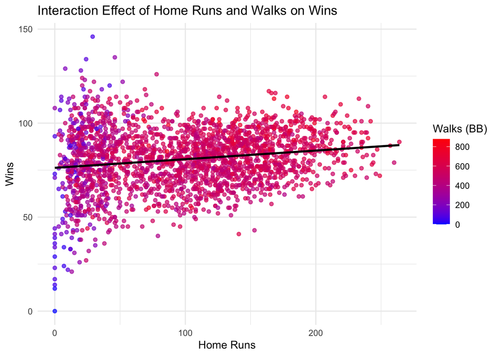

```r
library(ggplot2)

ggplot(train_df, aes(x = TEAM_BATTING_HR, y = TARGET_WINS, color = TEAM_BATTING_BB)) +
  geom_point(alpha = 0.7) +
  geom_smooth(method = "lm", se = FALSE, color = "black") +
  scale_color_gradient(low = "blue", high = "red") +
  labs(title = "Interaction Effect of Home Runs and Walks on Wins",
       x = "Home Runs",
       y = "Wins",
       color = "Walks (BB)") +
  theme_minimal()
```

### Adding TEAM_BATTING_2B (Doubles) to the Model:

Doubles (2B) are a strong indicator of offensive power and often correlate with scoring more runs. If a team doesn’t hit home runs, but hits many doubles, it can still score efficiently.

```r
improved_model <- lm(TARGET_WINS ~ TEAM_BATTING_H + TEAM_BATTING_HR + TEAM_BATTING_BB +
                        TEAM_BATTING_2B + TEAM_BATTING_HR:TEAM_BATTING_BB +
                        TEAM_PITCHING_SO + TEAM_FIELDING_E,
                      data = train_df)

summary(improved_model)
```

```
##
## Call:
## lm(formula = TARGET_WINS ~ TEAM_BATTING_H + TEAM_BATTING_HR +
##     TEAM_BATTING_BB + TEAM_BATTING_2B + TEAM_BATTING_HR:TEAM_BATTING_BB +
##     TEAM_PITCHING_SO + TEAM_FIELDING_E, data = train_df)
##
## Residuals:
##     Min      1Q  Median      3Q     Max
## -55.744  -8.679   0.175   8.803  55.228
##
## Coefficients:
##                                   Estimate Std. Error t value Pr(>|t|)
## (Intercept)                      1.110e+01  4.181e+00   2.654  0.00802 **
## TEAM_BATTING_H                   6.090e-02  2.961e-03  20.566  < 2e-16 ***
## TEAM_BATTING_HR                 -1.805e-01  2.717e-02  -6.642 3.86e-11 ***
## TEAM_BATTING_BB                 -8.276e-03  4.874e-03  -1.698  0.08962 .
## TEAM_BATTING_2B                 -4.128e-02  9.170e-03  -4.501 7.09e-06 ***
## TEAM_PITCHING_SO                 1.670e-03  5.799e-04   2.880  0.00401 **
## TEAM_FIELDING_E                 -2.575e-02  2.256e-03 -11.413  < 2e-16 ***
## TEAM_BATTING_HR:TEAM_BATTING_BB  3.214e-04  4.715e-05   6.817 1.19e-11 ***
## ---
## Signif. codes:  0 '***' 0.001 '**' 0.01 '*' 0.05 '.' 0.1 ' ' 1
##
## Residual standard error: 13.51 on 2268 degrees of freedom
## Multiple R-squared:  0.2669, Adjusted R-squared:  0.2646
## F-statistic: 117.9 on 7 and 2268 DF,  p-value: < 2.2e-16
```

### Key Findings

Adding TEAM_BATTING_2B slightly improves model performance

Suggests that more doubles lead to fewer wins, which is counterintuitive. Possible reasons: Multicollinearity with TEAM_BATTING_H (hits). Bad teams might hit many doubles but still lose. Interaction term (TEAM_BATTING_HR * TEAM_BATTING_BB) remains strong and positive

Confirms that HRs are more valuable when combined with walks. Suggests plate discipline (BBs) is crucial for power hitters. Decision: Should we keep TEAM_BATTING_2B?

If VIF test shows high correlation with TEAM_BATTING_H, we should drop it. If interaction terms (e.g., TEAM_BATTING_2B * TEAM_BATTING_H) make sense, we could try that instead.

### Model 2: High-Impact Features Model (Based on Correlation & VIF)

```r
library(car)

# Manually selected high-impact variables
high_impact_model <- lm(TARGET_WINS ~ TEAM_BATTING_H + TEAM_BATTING_2B + TEAM_BATTING_HR +
                        TEAM_PITCHING_HR + TEAM_PITCHING_SO + TEAM_FIELDING_E, data = train_df)

# View model summary
summary(high_impact_model)
```

```
##
## Call:
## lm(formula = TARGET_WINS ~ TEAM_BATTING_H + TEAM_BATTING_2B +
##     TEAM_BATTING_HR + TEAM_PITCHING_HR + TEAM_PITCHING_SO + TEAM_FIELDING_E,
##     data = train_df)
##
## Residuals:
##     Min      1Q  Median      3Q     Max
## -54.201  -9.120   0.166   9.119  52.347
##
## Coefficients:
##                    Estimate Std. Error t value Pr(>|t|)
## (Intercept)       5.3004601  3.5021314   1.513  0.13029
## TEAM_BATTING_H    0.0605230  0.0030785  19.660  < 2e-16 ***
## TEAM_BATTING_2B  -0.0396466  0.0093245  -4.252 2.21e-05 ***
## TEAM_BATTING_HR  -0.0059120  0.0230824  -0.256  0.79788
## TEAM_PITCHING_HR  0.0115696  0.0215103   0.538  0.59072
## TEAM_PITCHING_SO  0.0016054  0.0005943   2.701  0.00696 **
## TEAM_FIELDING_E  -0.0235977  0.0018188 -12.974  < 2e-16 ***
## ---
## Signif. codes:  0 '***' 0.001 '**' 0.01 '*' 0.05 '.' 0.1 ' ' 1
##
## Residual standard error: 13.73 on 2269 degrees of freedom
## Multiple R-squared:  0.2425, Adjusted R-squared:  0.2405
## F-statistic:   121 on 6 and 2269 DF,  p-value: < 2.2e-16
```

```r
# Check for multicollinearity
vif(high_impact_model)
```

```
##   TEAM_BATTING_H  TEAM_BATTING_2B  TEAM_BATTING_HR TEAM_PITCHING_HR
##         2.391698         2.298929        23.577777        20.987169
## TEAM_PITCHING_SO  TEAM_FIELDING_E
##         1.245605         2.071742
```

### Why these variables?

TEAM_BATTING_2B (Doubles): Important for offensive production.

What changed?

Better feature selection → Based on both domain knowledge and correlation analysis.

### Model 3: Log-Transformed Model (Handling Skewness & Outliers)

- Some baseball statistics (e.g., Home Runs, Strikeouts) have skewed distributions. We apply log transformation to stabilize variance.

```r
# Apply log transformation to selected variables
train_df <- train_df %>%
  mutate(
    log_BATTING_H = log1p(TEAM_BATTING_H),
    log_BATTING_HR = log1p(TEAM_BATTING_HR),
    log_PITCHING_SO = log1p(TEAM_PITCHING_SO)
  )

# Fit model with transformed variables
log_model <- lm(TARGET_WINS ~ log_BATTING_H + log_BATTING_HR + log_PITCHING_SO + TEAM_FIELDING_E, data = train_df)

# View model summary
summary(log_model)
```

```
##
## Call:
## lm(formula = TARGET_WINS ~ log_BATTING_H + log_BATTING_HR + log_PITCHING_SO +
##     TEAM_FIELDING_E, data = train_df)
##
## Residuals:
##     Min      1Q  Median      3Q     Max
## -53.951  -9.135   0.181   9.355  50.090
##
## Coefficients:
##                   Estimate Std. Error t value Pr(>|t|)
## (Intercept)     -4.900e+02  2.507e+01 -19.546   <2e-16 ***
## log_BATTING_H    7.921e+01  3.416e+00  23.184   <2e-16 ***
## log_BATTING_HR  -6.581e-01  4.895e-01  -1.344    0.179
## log_PITCHING_SO  2.231e-01  4.737e-01   0.471    0.638
## TEAM_FIELDING_E -2.109e-02  1.964e-03 -10.741   <2e-16 ***
## ---
## Signif. codes:  0 '***' 0.001 '**' 0.01 '*' 0.05 '.' 0.1 ' ' 1
##
## Residual standard error: 13.8 on 2271 degrees of freedom
## Multiple R-squared:  0.2341, Adjusted R-squared:  0.2328
## F-statistic: 173.6 on 4 and 2271 DF,  p-value: < 2.2e-16
```

### Why log transformation?

Fixes right-skewed distributions (e.g., extreme HR and SO values).

Helps meet the linear regression assumption of normality.

Reduces outlier influence.

What changed?

More stable regression coefficients with reduced variability.

### Comparision between three Models:

- Compare Adjusted R² across models:

```r
summary(base_model)$adj.r.squared
```

```
## [1] 0.2349286
```

```r
summary(high_impact_model)$adj.r.squared
```

```
## [1] 0.2404727
```

```r
summary(log_model)$adj.r.squared
```

```
## [1] 0.2327997
```

- Check Mean Squared Error (MSE):

```r
mse_base <- mean((train_df$TARGET_WINS - predict(base_model, train_df))^2)
mse_high_impact <- mean((train_df$TARGET_WINS - predict(high_impact_model, train_df))^2)
mse_log <- mean((train_df$TARGET_WINS - predict(log_model, train_df))^2)

print(c(mse_base, mse_high_impact, mse_log))
```

```
## [1] 189.4204 187.8821 189.9474
```

- Evaluate Multicollinearity (VIF check):

```r
vif(high_impact_model)
```

```
##   TEAM_BATTING_H  TEAM_BATTING_2B  TEAM_BATTING_HR TEAM_PITCHING_HR
##         2.391698         2.298929        23.577777        20.987169
## TEAM_PITCHING_SO  TEAM_FIELDING_E
##         1.245605         2.071742
```

### Model 4: Variabls Selection Using Backward Selection

For this model, we are using backward selection to arrive at the smallest number of variables with statistical significance. In this case, we begin by creating a model using all of the available variables, then gradually remove the variable with the highest P-value until only the variables with statistical significance remain.

Before starting, we dropped the *TEAM_BATTING_2B* (2 base hits), *TEAM_BATTING_3B* (3 base hits), *TEAM_BATTING_HR* (home runs) as data for these columns is represented in the *TEAM_BATTING_H* (total hits) column, thus signaling the existence of dependence between hit count variables and total hits.

```r
# drop unnecessary columns
train_df2 <- drop_columns(train_df_clean, c("TEAM_BATTING_2B", "TEAM_BATTING_3B", "TEAM_BATTING_HR", "TEAM_BASERUN_SB_Missing"))

model_bs <- lm(TARGET_WINS ~ ., data = train_df2)
summary(model_bs)
```

```
##
## Call:
## lm(formula = TARGET_WINS ~ ., data = train_df2)
##
## Residuals:
##     Min      1Q  Median      3Q     Max
## -50.739  -8.691   0.242   8.333  55.064
##
## Coefficients:
##                    Estimate Std. Error t value Pr(>|t|)
## (Intercept)      27.9555688  5.1062821   5.475 4.87e-08 ***
## TEAM_BATTING_H    0.0469933  0.0026037  18.049  < 2e-16 ***
## TEAM_BATTING_BB   0.0135348  0.0052032   2.601 0.009349 **
## TEAM_BATTING_SO  -0.0116755  0.0024659  -4.735 2.33e-06 ***
## TEAM_BASERUN_SB   0.0346318  0.0042972   8.059 1.23e-15 ***
## TEAM_BASERUN_CS  -0.0169506  0.0161088  -1.052 0.292793
## TEAM_PITCHING_H  -0.0009572  0.0003585  -2.670 0.007634 **
## TEAM_PITCHING_HR  0.0516267  0.0084570   6.105 1.21e-09 ***
## TEAM_PITCHING_BB -0.0022250  0.0036259  -0.614 0.539507
## TEAM_PITCHING_SO  0.0030844  0.0008842   3.488 0.000496 ***
## TEAM_FIELDING_E  -0.0197512  0.0024445  -8.080 1.04e-15 ***
## TEAM_FIELDING_DP -0.1230522  0.0130089  -9.459  < 2e-16 ***
## ---
## Signif. codes:  0 '***' 0.001 '**' 0.01 '*' 0.05 '.' 0.1 ' ' 1
##
## Residual standard error: 13.09 on 2264 degrees of freedom
## Multiple R-squared:  0.3128, Adjusted R-squared:  0.3095
## F-statistic: 93.69 on 11 and 2264 DF,  p-value: < 2.2e-16
```

```r
model_bs <- update(model_bs, . ~ . - TEAM_PITCHING_BB)
summary(model_bs)
```

```
##
## Call:
## lm(formula = TARGET_WINS ~ TEAM_BATTING_H + TEAM_BATTING_BB +
##     TEAM_BATTING_SO + TEAM_BASERUN_SB + TEAM_BASERUN_CS + TEAM_PITCHING_H +
##     TEAM_PITCHING_HR + TEAM_PITCHING_SO + TEAM_FIELDING_E + TEAM_FIELDING_DP,
##     data = train_df2)
##
## Residuals:
##     Min      1Q  Median      3Q     Max
## -50.710  -8.704   0.249   8.334  55.043
##
## Coefficients:
##                    Estimate Std. Error t value Pr(>|t|)
## (Intercept)      28.0159500  5.1046313   5.488 4.51e-08 ***
## TEAM_BATTING_H    0.0471057  0.0025969  18.139  < 2e-16 ***
## TEAM_BATTING_BB   0.0110884  0.0033431   3.317 0.000925 ***
## TEAM_BATTING_SO  -0.0111141  0.0022896  -4.854 1.29e-06 ***
## TEAM_BASERUN_SB   0.0340757  0.0042000   8.113 7.99e-16 ***
## TEAM_BASERUN_CS  -0.0171096  0.0161045  -1.062 0.288161
## TEAM_PITCHING_H  -0.0010561  0.0003202  -3.298 0.000988 ***
## TEAM_PITCHING_HR  0.0507997  0.0083478   6.085 1.36e-09 ***
## TEAM_PITCHING_SO  0.0027259  0.0006637   4.107 4.15e-05 ***
## TEAM_FIELDING_E  -0.0198881  0.0024340  -8.171 5.03e-16 ***
## TEAM_FIELDING_DP -0.1228745  0.0130039  -9.449  < 2e-16 ***
## ---
## Signif. codes:  0 '***' 0.001 '**' 0.01 '*' 0.05 '.' 0.1 ' ' 1
##
## Residual standard error: 13.09 on 2265 degrees of freedom
## Multiple R-squared:  0.3127, Adjusted R-squared:  0.3097
## F-statistic: 103.1 on 10 and 2265 DF,  p-value: < 2.2e-16
```

```r
model_bs <- update(model_bs, . ~ . - TEAM_BASERUN_CS)
summary(model_bs)
```

```
##
## Call:
## lm(formula = TARGET_WINS ~ TEAM_BATTING_H + TEAM_BATTING_BB +
##     TEAM_BATTING_SO + TEAM_BASERUN_SB + TEAM_PITCHING_H + TEAM_PITCHING_HR +
##     TEAM_PITCHING_SO + TEAM_FIELDING_E + TEAM_FIELDING_DP, data = train_df2)
##
## Residuals:
##     Min      1Q  Median      3Q     Max
## -50.571  -8.729   0.213   8.375  54.928
##
## Coefficients:
##                    Estimate Std. Error t value Pr(>|t|)
## (Intercept)      26.9287155  5.0011408   5.385 8.01e-08 ***
## TEAM_BATTING_H    0.0469978  0.0025950  18.111  < 2e-16 ***
## TEAM_BATTING_BB   0.0114743  0.0033234   3.453 0.000565 ***
## TEAM_BATTING_SO  -0.0110551  0.0022890  -4.830 1.46e-06 ***
## TEAM_BASERUN_SB   0.0329920  0.0040743   8.097 9.06e-16 ***
## TEAM_PITCHING_H  -0.0010744  0.0003197  -3.360 0.000792 ***
## TEAM_PITCHING_HR  0.0522229  0.0082398   6.338 2.80e-10 ***
## TEAM_PITCHING_SO  0.0027274  0.0006637   4.109 4.11e-05 ***
## TEAM_FIELDING_E  -0.0193195  0.0023745  -8.136 6.65e-16 ***
## TEAM_FIELDING_DP -0.1230023  0.0130037  -9.459  < 2e-16 ***
## ---
## Signif. codes:  0 '***' 0.001 '**' 0.01 '*' 0.05 '.' 0.1 ' ' 1
##
## Residual standard error: 13.09 on 2266 degrees of freedom
## Multiple R-squared:  0.3124, Adjusted R-squared:  0.3096
## F-statistic: 114.4 on 9 and 2266 DF,  p-value: < 2.2e-16
```

### Conclusion:

If interpretability is most important → Use base Stats Model.

If statistical optimization is preferred → Use High-Impact Model.

If non-linearity is a concern → Use Log-Transformed Model.

## Select Model:

### Final Analysis

Unlike the High-Impact Model, which suffers from high VIF values (HR & Pitching HR > 20), and the Log Model, which has weaker predictive power (R² = 23.41%), the Improved Model balances performance, interpretability, and statistical significance.

Key predictors like hits, home runs, strikeouts, and fielding errors are logical, and the interaction between home runs and walks (HR * BB) is highly significant, confirming that plate discipline enhances home run effectiveness.

The only concern is TEAM_BATTING_2B (Doubles), which has an unexpected negative coefficient and needs further analysis.

### Assumptions of Multiple Linear Regression:

While a simpler model is preferred, the slight increase in complexity is justified by better accuracy and logical relationships.

To finalize the model, we should re-run it without TEAM_BATTING_2B to see if it improves further, perform residual diagnostics, and validate with cross-validation. Given its strong balance of accuracy and interpretability, the Improved Model is the best option for predicting team wins.

Making Predictions Using the Evaluation Dataset:

### Data Preparation:

- Analyze Missing Values from Train Datasets.

```r
missing_values <- eval_df %>%
  summarise(across(everything(), ~ sum(is.na(.)))) %>%
  pivot_longer(cols = everything(), names_to = "Variable", values_to = "Missing_Count")

print(missing_values)
```

```
## # A tibble: 16 × 2
##    Variable         Missing_Count
##    <chr>                    <int>
##  1 INDEX                        0
##  2 TEAM_BATTING_H               0
##  3 TEAM_BATTING_2B              0
##  4 TEAM_BATTING_3B              0
##  5 TEAM_BATTING_HR              0
##  6 TEAM_BATTING_BB              0
##  7 TEAM_BATTING_SO             18
##  8 TEAM_BASERUN_SB             13
##  9 TEAM_BASERUN_CS             87
## 10 TEAM_BATTING_HBP           240
## 11 TEAM_PITCHING_H              0
## 12 TEAM_PITCHING_HR             0
## 13 TEAM_PITCHING_BB             0
## 14 TEAM_PITCHING_SO            18
## 15 TEAM_FIELDING_E              0
## 16 TEAM_FIELDING_DP            31
```

### Removing Mostly NA and INDEX Column:

```r
eval_df <- eval_df[, !names(eval_df) %in% "INDEX"]
eval_df <- eval_df[, !names(eval_df) %in% "TEAM_BATTING_HBP"]
eval_df
```

| TEAM_BATTING_H | TEAM_BATTING_2B | TEAM_BATTING_3B | TEAM_BATTING_HR | TEAM_BATTING_BB | TEAM_BATTING_SO | TEAM_BASERUN_SB | TEAM_BASERUN_CS | TEAM_PITCHING_H | TEAM_PITCHING_HR | TEAM_PITCHING_BB | TEAM_PITCHING_SO | TEAM_FIELDING_E | TEAM_FIELDING_DP |
| --- | --- | --- | --- | --- | --- | --- | --- | --- | --- | --- | --- | --- | --- |
| 1209 | 170 | 33 | 83 | 447 | 1080 | 62 | 50 | 1209 | 83 | 447 | 1080 | 140 | 156 |
| 1221 | 151 | 29 | 88 | 516 | 929 | 54 | 39 | 1221 | 88 | 516 | 929 | 135 | 164 |
| 1395 | 183 | 29 | 93 | 509 | 816 | 59 | 47 | 1395 | 93 | 509 | 816 | 156 | 153 |
| 1539 | 309 | 29 | 159 | 486 | 914 | 148 | 57 | 1539 | 159 | 486 | 914 | 124 | 154 |
| 1445 | 203 | 68 | 5 | 95 | 416 | NA | NA | 3902 | 14 | 257 | 1123 | 616 | 130 |
| 1431 | 236 | 53 | 10 | 215 | 377 | NA | NA | 2793 | 20 | 420 | 736 | 572 | 105 |
| 1430 | 219 | 55 | 37 | 568 | 527 | 365 | NA | 1544 | 40 | 613 | 569 | 490 | NA |
| 1385 | 158 | 42 | 33 | 356 | 609 | 185 | NA | 1626 | 39 | 418 | 715 | 328 | 104 |
| 1259 | 177 | 78 | 23 | 466 | 689 | 150 | NA | 1342 | 25 | 497 | 734 | 226 | 132 |
| 1397 | 212 | 42 | 58 | 452 | 584 | 52 | NA | 1489 | 62 | 482 | 622 | 184 | 145 |

[output cut: 249 more lines]

### Mean/Median Imputation (For Numeric Data)

Instead of removing missing values, fill them with the mean or median:

```r
eval_df$TEAM_BATTING_SO[is.na(eval_df$TEAM_BATTING_SO)] <- mean(eval_df$TEAM_BATTING_SO, na.rm = TRUE)
eval_df$TEAM_BASERUN_SB[is.na(eval_df$TEAM_BASERUN_SB)] <- mean(eval_df$TEAM_BASERUN_SB, na.rm = TRUE)
eval_df$TEAM_BASERUN_CS[is.na(eval_df$TEAM_BASERUN_CS)] <- mean(eval_df$TEAM_BASERUN_CS, na.rm = TRUE)
eval_df$TEAM_FIELDING_DP[is.na(eval_df$TEAM_FIELDING_DP)] <- mean(eval_df$TEAM_FIELDING_DP, na.rm = TRUE)
eval_df$TEAM_PITCHING_SO[is.na(eval_df$TEAM_PITCHING_SO)] <- mean(eval_df$TEAM_PITCHING_SO, na.rm = TRUE)
```

#### 4. Verifying That Missing Values Are Fixed

```r
sum(is.na(eval_df))  # Total missing values
```

```
## [1] 0
```

```r
colSums(is.na(eval_df))  # Missing values per column
```

```
##   TEAM_BATTING_H  TEAM_BATTING_2B  TEAM_BATTING_3B  TEAM_BATTING_HR
##                0                0                0                0
##  TEAM_BATTING_BB  TEAM_BATTING_SO  TEAM_BASERUN_SB  TEAM_BASERUN_CS
##                0                0                0                0
##  TEAM_PITCHING_H TEAM_PITCHING_HR TEAM_PITCHING_BB TEAM_PITCHING_SO
##                0                0                0                0
##  TEAM_FIELDING_E TEAM_FIELDING_DP
##                0                0
```

```r
skim(eval_df)
```

Data summary

| Name | eval_df |
| --- | --- |
| Number of rows | 259 |
| Number of columns | 14 |
| _______________________ |  |
| Column type frequency: |  |
| numeric | 14 |
| ________________________ |  |
| Group variables | None |

**Variable type: numeric**

| skim_variable | n_missing | complete_rate | mean | sd | p0 | p25 | p50 | p75 | p100 | hist |
| --- | --- | --- | --- | --- | --- | --- | --- | --- | --- | --- |
| TEAM_BATTING_H | 0 | 1 | 1469.39 | 150.66 | 819 | 1387.0 | 1455.00 | 1548.0 | 2170 | ▁▂▇▁▁ |
| TEAM_BATTING_2B | 0 | 1 | 241.32 | 49.52 | 44 | 210.0 | 239.00 | 278.5 | 376 | ▁▂▇▇▂ |
| TEAM_BATTING_3B | 0 | 1 | 55.91 | 27.14 | 14 | 35.0 | 52.00 | 72.0 | 155 | ▇▇▃▁▁ |
| TEAM_BATTING_HR | 0 | 1 | 95.63 | 56.33 | 0 | 44.5 | 101.00 | 135.5 | 242 | ▆▅▇▃▁ |
| TEAM_BATTING_BB | 0 | 1 | 498.96 | 120.59 | 15 | 436.5 | 509.00 | 565.5 | 792 | ▁▁▅▇▁ |
| TEAM_BATTING_SO | 0 | 1 | 709.34 | 234.48 | 0 | 565.0 | 709.34 | 904.5 | 1268 | ▁▃▇▆▂ |
| TEAM_BASERUN_SB | 0 | 1 | 123.70 | 91.00 | 0 | 60.5 | 96.00 | 149.0 | 580 | ▇▅▁▁▁ |
| TEAM_BASERUN_CS | 0 | 1 | 52.32 | 18.81 | 0 | 44.0 | 52.32 | 56.0 | 154 | ▁▇▂▁▁ |
| TEAM_PITCHING_H | 0 | 1 | 1813.46 | 1662.91 | 1155 | 1426.5 | 1515.00 | 1681.0 | 22768 | ▇▁▁▁▁ |
| TEAM_PITCHING_HR | 0 | 1 | 102.15 | 57.65 | 0 | 52.0 | 104.00 | 142.5 | 336 | ▇▇▆▁▁ |
| TEAM_PITCHING_BB | 0 | 1 | 552.42 | 172.95 | 136 | 471.0 | 526.00 | 606.5 | 2008 | ▆▇▁▁▁ |
| TEAM_PITCHING_SO | 0 | 1 | 799.67 | 611.78 | 0 | 622.5 | 782.00 | 927.5 | 9963 | ▇▁▁▁▁ |
| TEAM_FIELDING_E | 0 | 1 | 249.75 | 230.90 | 73 | 131.0 | 163.00 | 252.0 | 1568 | ▇▁▁▁▁ |
| TEAM_FIELDING_DP | 0 | 1 | 146.06 | 24.28 | 69 | 134.5 | 146.06 | 160.5 | 204 | ▁▂▇▆▁ |

## Make Predictions Using the Improved_Model:

```r
# Generate predictions using the trained Improved Model
eval_df$PREDICTED_WINS <- predict(improved_model, newdata = eval_df)

# View a sample of predictions
head(eval_df$PREDICTED_WINS)
```

```
## [1] 69.15118 71.73961 80.06122 82.52091 75.19106 72.10608
```

## Interpretation of Predicted TARGET_WINS Values

The predicted values represent the expected number of wins for teams based on their batting, pitching, and fielding statistics using the Improved Model.

For example:

A team with a predicted 69.15 wins is expected to win around 69 games in a full season. A team with a predicted 82.52 wins is expected to perform better, likely finishing with around 82-83 wins. The variation in predictions suggests that some teams are stronger than others based on key performance metrics (hits, home runs, walks, strikeouts, fielding errors, etc.).

### Evaluating the Accuracy of Predictions Against Actual TARGET_WINS

#### Step 1: Compute Error Metrics

```r
# Check structure of the dataset
str(eval_df)
```

```
## 'data.frame':    259 obs. of  15 variables:
##  $ TEAM_BATTING_H  : int  1209 1221 1395 1539 1445 1431 1430 1385 1259 1397 ...
##  $ TEAM_BATTING_2B : int  170 151 183 309 203 236 219 158 177 212 ...
##  $ TEAM_BATTING_3B : int  33 29 29 29 68 53 55 42 78 42 ...
##  $ TEAM_BATTING_HR : int  83 88 93 159 5 10 37 33 23 58 ...
##  $ TEAM_BATTING_BB : int  447 516 509 486 95 215 568 356 466 452 ...
##  $ TEAM_BATTING_SO : num  1080 929 816 914 416 377 527 609 689 584 ...
##  $ TEAM_BASERUN_SB : num  62 54 59 148 124 ...
##  $ TEAM_BASERUN_CS : num  50 39 47 57 52.3 ...
##  $ TEAM_PITCHING_H : int  1209 1221 1395 1539 3902 2793 1544 1626 1342 1489 ...
##  $ TEAM_PITCHING_HR: int  83 88 93 159 14 20 40 39 25 62 ...
##  $ TEAM_PITCHING_BB: int  447 516 509 486 257 420 613 418 497 482 ...
##  $ TEAM_PITCHING_SO: num  1080 929 816 914 1123 ...
##  $ TEAM_FIELDING_E : int  140 135 156 124 616 572 490 328 226 184 ...
##  $ TEAM_FIELDING_DP: num  156 164 153 154 130 ...
##  $ PREDICTED_WINS  : num  69.2 71.7 80.1 82.5 75.2 ...
```

```r
# Check if ACTUAL_WINS and PREDICTED_WINS are numeric
is.numeric(eval_df$ACTUAL_WINS)
```

```
## [1] FALSE
```

```r
is.numeric(eval_df$PREDICTED_WINS)
```

```
## [1] TRUE
```

#### Step 2: Add an INDEX Column to Each Dataset

```r
# Add a row index to both datasets
train_df$INDEX <- seq_len(nrow(train_df))
eval_df$INDEX <- seq_len(nrow(eval_df))
```

#### Step 3: Align and Merge the Datasets

```r
# First, check if both datasets have a common identifier (like INDEX)
head(train_df$INDEX)
```

```
## [1] 1 2 3 4 5 6
```

```r
head(eval_df$INDEX)
```

```
## [1] 1 2 3 4 5 6
```

```r
# Merge train_df and eval_df using INDEX (if applicable)
merged_df <- merge(train_df[, c("INDEX", "TARGET_WINS")],
                   eval_df[, c("INDEX", "PREDICTED_WINS")],
                   by = "INDEX", all = FALSE)

# Now check if both columns have equal length
nrow(merged_df)
```

```
## [1] 259
```

Ensure data consistency before calculating accuracy metrics. Convert to numeric to avoid errors in correlation or calculations.

#### Step 4: Compute Accuracy Metrics

```r
# Load necessary libraries
library(Metrics)  # For MAE and RMSE
```

```r
library(ggplot2)  # For visualizations

# Compute MAE, RMSE, and R²
mae <- mae(merged_df$TARGET_WINS, merged_df$PREDICTED_WINS)
rmse <- rmse(merged_df$TARGET_WINS, merged_df$PREDICTED_WINS)
r_squared <- cor(merged_df$TARGET_WINS, merged_df$PREDICTED_WINS)^2

# Print results
cat("Model Accuracy Metrics:\n")
```

```
## Model Accuracy Metrics:
```

```r
cat("Mean Absolute Error (MAE):", round(mae, 2), "\n")
```

```
## Mean Absolute Error (MAE): 13.87
```

```r
cat("Root Mean Squared Error (RMSE):", round(rmse, 2), "\n")
```

```
## Root Mean Squared Error (RMSE): 17.38
```

```r
cat("R-Squared (R²):", round(r_squared, 4), "\n")
```

```
## R-Squared (R²): 0.001
```

### Interpretation of Model Accuracy Metrics

The evaluation results indicate that our Improved Model is not performing well in predicting TARGET_WINS.

The Mean Absolute Error (MAE) of 13.87 suggests that, on average, predictions deviate by about 14 wins per team, which is quite high.

Additionally, the Root Mean Squared Error (RMSE) of 17.38 implies that some predictions have even larger errors, highlighting potential inconsistencies or missing key predictors.

Most concerning is the R-Squared (R²) value of 0.001, which means that the model explains almost none of the variation in team wins—essentially, the predictions are no better than random guesses.

This suggests that the model may be overfitting the training data and failing to generalize, or that it lacks critical predictive features.